# 6. Diabetes Percentage with Tax

### Importing necessary libraries

```python
import pandas as pd
import numpy as np
import seaborn as sns
import matplotlib.pyplot as plt
import statsmodels.api as sm

# code to ignore warnings
import warnings
warnings.filterwarnings("ignore")

root_csv = '../csv files/'
root_pickle = '../pickle files/'
```

### Reading files

```python
df_diab_total_pivot = pd.read_pickle(root_pickle +'Diabetes_Total_Pivot.pkl')
df_diab_gender_pivot = pd.read_pickle(root_pickle +'Diabetes_Gender_Pivot.pkl')
df_diab_age_pivot = pd.read_pickle(root_pickle +'Diabetes_Age_Pivot.pkl')
```

### Reviewing data

```python
df_diab_total_pivot.head(5)
```

|  | State | County | CountyFIPS | Year | Total Absolute | Total Percentage | Grocery Tax | Restaurant Tax | tax_delta | Population |
| --- | --- | --- | --- | --- | --- | --- | --- | --- | --- | --- |
| 0 | Alabama | Autauga County | 1001 | 2004 | 2470.0 | 7.5 | 0.04 | 0.04 | 0.0 | 32933.333333 |
| 6 | Alabama | Autauga County | 1001 | 2005 | 3010.0 | 8.9 | 0.04 | 0.04 | 0.0 | 33820.226169 |
| 12 | Alabama | Autauga County | 1001 | 2006 | 3482.0 | 10.0 | 0.04 | 0.04 | 0.0 | 34820.000000 |
| 18 | Alabama | Autauga County | 1001 | 2007 | 3332.0 | 9.4 | 0.04 | 0.04 | 0.0 | 35446.809949 |
| 24 | Alabama | Autauga County | 1001 | 2008 | 3563.0 | 9.9 | 0.04 | 0.04 | 0.0 | 35989.900377 |

```python
df_diab_gender_pivot.head(5)
```

|  | State | County | CountyFIPS | Year | Gender Absolute | Gender Percentage | Gender | Grocery Tax | Restaurant Tax | tax_delta | Population |
| --- | --- | --- | --- | --- | --- | --- | --- | --- | --- | --- | --- |
| 0 | Alabama | Autauga County | 1001 | 2004 | 1281.0 | 7.4 | Female | 0.04 | 0.04 | 0.0 | 17310.810588 |
| 3 | Alabama | Autauga County | 1001 | 2004 | 1189.0 | 7.6 | Male | 0.04 | 0.04 | 0.0 | 15644.737038 |
| 6 | Alabama | Autauga County | 1001 | 2005 | 1523.0 | 8.6 | Female | 0.04 | 0.04 | 0.0 | 17709.301540 |
| 9 | Alabama | Autauga County | 1001 | 2005 | 1487.0 | 9.3 | Male | 0.04 | 0.04 | 0.0 | 15989.246984 |
| 12 | Alabama | Autauga County | 1001 | 2006 | 1758.0 | 9.7 | Female | 0.04 | 0.04 | 0.0 | 18123.711697 |

```python
df_diab_age_pivot.head(5)
```

|  | State | County | CountyFIPS | Year | Age Diabetics Absolute | Age Diabetics Percentage | Age | Grocery Tax | Restaurant Tax | tax_delta | Population |
| --- | --- | --- | --- | --- | --- | --- | --- | --- | --- | --- | --- |
| 0 | Alabama | Autauga County | 1001 | 2004 | 472.0 | 2.900000 | 20-44 | 0.04 | 0.04 | 0.0 | 16275.861534 |
| 1 | Alabama | Autauga County | 1001 | 2004 | 1179.0 | 10.300000 | 45-64 | 0.04 | 0.04 | 0.0 | 11446.601730 |
| 2 | Alabama | Autauga County | 1001 | 2004 | 819.0 | 16.299999 | 65-beyond | 0.04 | 0.04 | 0.0 | 5024.540112 |
| 6 | Alabama | Autauga County | 1001 | 2005 | 582.0 | 3.500000 | 20-44 | 0.04 | 0.04 | 0.0 | 16628.571429 |
| 7 | Alabama | Autauga County | 1001 | 2005 | 1458.0 | 12.300000 | 45-64 | 0.04 | 0.04 | 0.0 | 11853.658353 |

### Regression Analysis at County level data

#### 1. Baseline without controls

##### a. With Total Percentage as Response Variable:

```python
import numpy as np
import pandas as pd
import statsmodels.api as sm
from sklearn.model_selection import train_test_split
from sklearn.linear_model import LinearRegression
from sklearn.metrics import mean_squared_error, r2_score

# Assuming 'Grocery Tax' and 'Restaurant Tax' are the features
X = df_diab_total_pivot[['Grocery Tax', 'Restaurant Tax']]
y = df_diab_total_pivot['Total Percentage']

# Add a constant term to the features matrix (required for statsmodels)
X = sm.add_constant(X)

# Create and fit the linear regression model using statsmodels
stats_model = sm.OLS(y, X).fit()

# Print the summary
print(stats_model.summary())
```

```
                            OLS Regression Results
==============================================================================
Dep. Variable:       Total Percentage   R-squared:                       0.020
Model:                            OLS   Adj. R-squared:                  0.020
Method:                 Least Squares   F-statistic:                     546.9
Date:                Sat, 25 Nov 2023   Prob (F-statistic):          7.86e-236
Time:                        15:08:11   Log-Likelihood:            -1.1262e+05
No. Observations:               53318   AIC:                         2.252e+05
Df Residuals:                   53315   BIC:                         2.253e+05
Df Model:                           2
Covariance Type:            nonrobust
==================================================================================
                     coef    std err          t      P>|t|      [0.025      0.975]
----------------------------------------------------------------------------------
const              8.9058      0.028    315.522      0.000       8.850       8.961
Grocery Tax       12.2786      0.417     29.471      0.000      11.462      13.095
Restaurant Tax     5.5515      0.518     10.715      0.000       4.536       6.567
==============================================================================
Omnibus:                     3382.565   Durbin-Watson:                   0.492
Prob(Omnibus):                  0.000   Jarque-Bera (JB):             4431.049
Skew:                           0.589   Prob(JB):                         0.00
Kurtosis:                       3.778   Cond. No.                         60.9
==============================================================================

Notes:
[1] Standard Errors assume that the covariance matrix of the errors is correctly specified.
```

##### Conclusions:

The baseline model with response as total percentage of diabetics and predictor variables grocery tax and restaurant tax:

- One percent increase in grocery tax, keeping all other constant, increases the percentage of diabetics by 12.27%
- One percent increase in restaurant tax, keeping all other constant, increases the percentage of diabetics by 5.55%
- p-value is close to 0 in both cases. Hence the coefficients of regression are statistically significant
- Adjusted R-square is 0.02 indicating that the model can explain only 2.0% of variation in total number of diabetics patient
- This model was fitted without taking into account affects of other factors such as age, gender, ethinicity etc.

#### 2. With single controls

##### a. Gender Control - On Percentage

```python
import numpy as np
import pandas as pd
import statsmodels.api as sm
from sklearn.model_selection import train_test_split
from sklearn.linear_model import LinearRegression
from sklearn.metrics import mean_squared_error, r2_score

# One Hot Encoding Gender in predictor variable
X = pd.get_dummies(df_diab_gender_pivot[['Grocery Tax', 'Restaurant Tax', 'Gender']], columns=['Gender'], drop_first=True)
y = df_diab_gender_pivot['Gender Percentage']

# Add a constant term to the features matrix (required for statsmodels)
X = sm.add_constant(X)

# Create and fit the linear regression model using statsmodels
stats_model = sm.OLS(y, X).fit()

# Print the summary
print(stats_model.summary())
```

```
                            OLS Regression Results
==============================================================================
Dep. Variable:      Gender Percentage   R-squared:                       0.050
Model:                            OLS   Adj. R-squared:                  0.050
Method:                 Least Squares   F-statistic:                     1890.
Date:                Sat, 25 Nov 2023   Prob (F-statistic):               0.00
Time:                        15:08:12   Log-Likelihood:            -2.2728e+05
No. Observations:              106631   AIC:                         4.546e+05
Df Residuals:                  106627   BIC:                         4.546e+05
Df Model:                           3
Covariance Type:            nonrobust
==================================================================================
                     coef    std err          t      P>|t|      [0.025      0.975]
----------------------------------------------------------------------------------
const              8.5390      0.021    401.221      0.000       8.497       8.581
Grocery Tax       12.2272      0.300     40.714      0.000      11.639      12.816
Restaurant Tax     5.6328      0.373     15.082      0.000       4.901       6.365
Gender_Male        0.7462      0.012     59.750      0.000       0.722       0.771
==============================================================================
Omnibus:                     7456.321   Durbin-Watson:                   0.375
Prob(Omnibus):                  0.000   Jarque-Bera (JB):            10117.821
Skew:                           0.617   Prob(JB):                         0.00
Kurtosis:                       3.868   Cond. No.                         69.7
==============================================================================

Notes:
[1] Standard Errors assume that the covariance matrix of the errors is correctly specified.
```

##### b. Age Control - On Percentage

```python
import numpy as np
import pandas as pd
import statsmodels.api as sm
from sklearn.model_selection import train_test_split
from sklearn.linear_model import LinearRegression
from sklearn.metrics import mean_squared_error, r2_score

# One Hot Encoding Gender in predictor variable
X = pd.get_dummies(df_diab_age_pivot[['Grocery Tax', 'Restaurant Tax', 'Age']], columns=['Age'], drop_first=True)
y = df_diab_age_pivot['Age Diabetics Percentage']

# Add a constant term to the features matrix (required for statsmodels)
X = sm.add_constant(X)

# Create and fit the linear regression model using statsmodels
stats_model = sm.OLS(y, X).fit()

# Print the summary
print(stats_model.summary())
```

```
                               OLS Regression Results
====================================================================================
Dep. Variable:     Age Diabetics Percentage   R-squared:                       0.865
Model:                                  OLS   Adj. R-squared:                  0.865
Method:                       Least Squares   F-statistic:                 2.536e+05
Date:                      Sat, 25 Nov 2023   Prob (F-statistic):               0.00
Time:                              15:08:12   Log-Likelihood:            -3.6586e+05
No. Observations:                    158645   AIC:                         7.317e+05
Df Residuals:                        158640   BIC:                         7.318e+05
Df Model:                                 4
Covariance Type:                  nonrobust
==================================================================================
                     coef    std err          t      P>|t|      [0.025      0.975]
----------------------------------------------------------------------------------
const              2.4254      0.022    110.876      0.000       2.383       2.468
Grocery Tax       14.7660      0.293     50.404      0.000      14.192      15.340
Restaurant Tax     4.9229      0.367     13.425      0.000       4.204       5.642
Age_45-64          8.5423      0.015    570.815      0.000       8.513       8.572
Age_65-beyond     15.0130      0.015   1003.154      0.000      14.984      15.042
==============================================================================
Omnibus:                    29968.707   Durbin-Watson:                   0.769
Prob(Omnibus):                  0.000   Jarque-Bera (JB):            83309.051
Skew:                           1.012   Prob(JB):                         0.00
Kurtosis:                       5.917   Cond. No.                         68.4
==============================================================================

Notes:
[1] Standard Errors assume that the covariance matrix of the errors is correctly specified.
```

##### Conclusion:

The model with response as percentage of diabetics and predictor variables grocery tax and restaurant tax and control on age:

- One percent increase in grocery tax, keeping all other constant, increases the percentage by 14.76%
- One percent increase in restaurant tax, keeping all other constant, increases the percentage by 4.93%
- If the age is between 45-64, keeping all other constant, the percentage increases by 8.54%.
- If the age is between 65-beyond, keeping all other constant, the percentage increases by 15.01%.
- All p values are statistically significant
- Adjusted R-square is 0.865 indicating that the model can explain only 86.5% of variation in percentage of diabetics patient
- There is a significant increase in R-square. Since we fit linear model, we will have to validate its assumptions

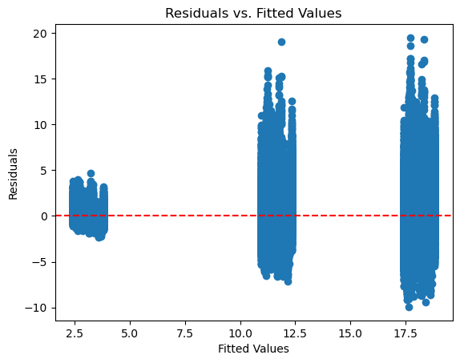

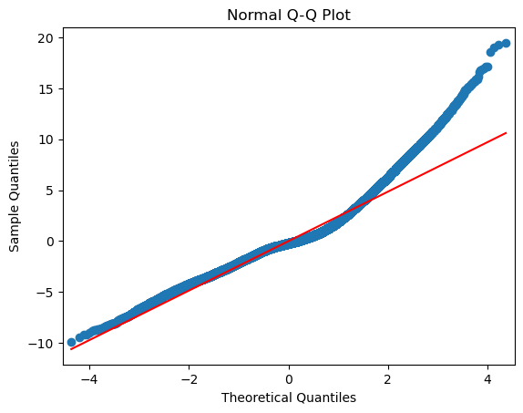

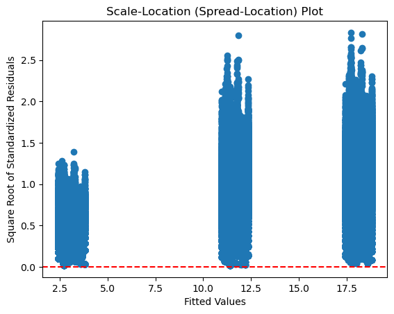

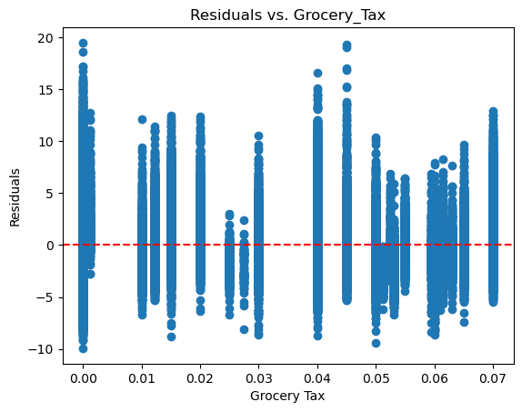

```python
# Checking linearity assumptions

import statsmodels.api as sm
import matplotlib.pyplot as plt
import scipy.stats as stats
import numpy as np

# Assuming you have already fitted the linear regression model named 'model'

# Get fitted values and residuals
fitted_values = stats_model.fittedvalues
residuals = stats_model.resid

# 1. Residuals vs. Fitted Values Plot
plt.scatter(fitted_values, residuals)
plt.xlabel('Fitted Values')
plt.ylabel('Residuals')
plt.title('Residuals vs. Fitted Values')
plt.axhline(y=0, color='r', linestyle='--')  # Add a horizontal line at y=0
plt.show()

# 2. Normal Q-Q Plot
sm.qqplot(residuals, line='s')
plt.title('Normal Q-Q Plot')
plt.show()

# 3. Scale-Location (Spread-Location) Plot
sqrt_standardized_residuals = np.sqrt(np.abs(stats_model.get_influence().resid_studentized_internal))
plt.scatter(fitted_values, sqrt_standardized_residuals)
plt.xlabel('Fitted Values')
plt.ylabel('Square Root of Standardized Residuals')
plt.title('Scale-Location (Spread-Location) Plot')
plt.axhline(y=0, color='r', linestyle='--')  # Add a horizontal line at y=0
plt.show()

# 4. Residuals vs. Predictor Plot for 'Grocery Tax'
plt.scatter(df_diab_age_pivot['Grocery Tax'], residuals)
plt.xlabel('Grocery Tax')
plt.ylabel('Residuals')
plt.title('Residuals vs. Grocery_Tax')
plt.axhline(y=0, color='r', linestyle='--')  # Add a horizontal line at y=0
plt.show()
```

##### Conclusions:

For the control model with age on response variable percentage diabetics, we observe that the assumptions are violated. Hence, we are applying transformation to provide remedy.

```python
#### Applying the Box-Cox transformation

# Apply Box-Cox Transformation to Response Variable
y_transformed, lambda_value = stats.boxcox(y + 1)  # Adding 1 to handle zero values

# Visualize the Transformed Response Variable
plt.hist(y_transformed, bins=20, edgecolor='black')
plt.title('Histogram of Transformed Response Variable')
plt.show()

# Check Lambda Value
print(f'Lambda Value: {lambda_value}')

# Fit a new model using the transformed response variable
stats_model_transformed = sm.OLS(y_transformed, X).fit()

# Print the summary of the transformed model
print(stats_model_transformed.summary())
```

[output not shown]

```
Lambda Value: 0.5100811843716125
                            OLS Regression Results
==============================================================================
Dep. Variable:                      y   R-squared:                       0.909
Model:                            OLS   Adj. R-squared:                  0.909
Method:                 Least Squares   F-statistic:                 3.968e+05
Date:                Sat, 25 Nov 2023   Prob (F-statistic):               0.00
Time:                        15:08:17   Log-Likelihood:            -1.5272e+05
No. Observations:              158645   AIC:                         3.054e+05
Df Residuals:                  158640   BIC:                         3.055e+05
Df Model:                           4
Covariance Type:            nonrobust
==================================================================================
                     coef    std err          t      P>|t|      [0.025      0.975]
----------------------------------------------------------------------------------
const              1.8179      0.006    318.494      0.000       1.807       1.829
Grocery Tax        4.1910      0.076     54.829      0.000       4.041       4.341
Restaurant Tax     1.2254      0.096     12.807      0.000       1.038       1.413
Age_45-64          3.1536      0.004    807.622      0.000       3.146       3.161
Age_65-beyond      4.8476      0.004   1241.405      0.000       4.840       4.855
==============================================================================
Omnibus:                    14084.319   Durbin-Watson:                   0.518
Prob(Omnibus):                  0.000   Jarque-Bera (JB):            22887.435
Skew:                           0.663   Prob(JB):                         0.00
Kurtosis:                       4.306   Cond. No.                         68.4
==============================================================================

Notes:
[1] Standard Errors assume that the covariance matrix of the errors is correctly specified.
```

##### Conclusions:

- The lambda value of transformation is 0.51
- For this lambda value, the model response variable (y) = % diabetics is now transformed to (((y^0.51)-1)/0.51) or (((%diabetics ^0.51)-1)/0.51)
- This changes some of the inferences. ##### New Inferences:
- A one unit increase in grocery tax increases transformed y by 4.19%
- A one unit increase in restaurant tax increases transformed y by 1.23%
- If the age bucket is 45-65, there is an increase in transformed y by 3.15%
- If the age bucket is 65-beyond, there is an increase in transformed y by 4.85%
- Adj R-square is 90.9% indicating the model explains 90.9% variability in transformed y.

##### c. Total Population Control - On Percentage

```python
import numpy as np
import pandas as pd
import statsmodels.api as sm
from sklearn.model_selection import train_test_split
from sklearn.linear_model import LinearRegression
from sklearn.metrics import mean_squared_error, r2_score

# Assuming 'Grocery Tax' and 'Restaurant Tax' are the features
X = df_diab_total_pivot[['Grocery Tax', 'Restaurant Tax','Population']]
y = df_diab_total_pivot['Total Percentage']

# Add a constant term to the features matrix (required for statsmodels)
X = sm.add_constant(X)

# Create and fit the linear regression model using statsmodels
stats_model = sm.OLS(y, X).fit()

# Print the summary
print(stats_model.summary())
```

```
                            OLS Regression Results
==============================================================================
Dep. Variable:       Total Percentage   R-squared:                       0.023
Model:                            OLS   Adj. R-squared:                  0.023
Method:                 Least Squares   F-statistic:                     410.2
Date:                Sat, 25 Nov 2023   Prob (F-statistic):          1.72e-263
Time:                        15:08:17   Log-Likelihood:            -1.1255e+05
No. Observations:               53318   AIC:                         2.251e+05
Df Residuals:                   53314   BIC:                         2.252e+05
Df Model:                           3
Covariance Type:            nonrobust
==================================================================================
                     coef    std err          t      P>|t|      [0.025      0.975]
----------------------------------------------------------------------------------
const              8.9167      0.028    316.127      0.000       8.861       8.972
Grocery Tax       11.7732      0.418     28.139      0.000      10.953      12.593
Restaurant Tax     6.0656      0.519     11.679      0.000       5.048       7.084
Population     -4.301e-07   3.71e-08    -11.585      0.000   -5.03e-07   -3.57e-07
==============================================================================
Omnibus:                     3366.050   Durbin-Watson:                   0.493
Prob(Omnibus):                  0.000   Jarque-Bera (JB):             4386.463
Skew:                           0.590   Prob(JB):                         0.00
Kurtosis:                       3.764   Cond. No.                     1.51e+07
==============================================================================

Notes:
[1] Standard Errors assume that the covariance matrix of the errors is correctly specified.
[2] The condition number is large, 1.51e+07. This might indicate that there are
strong multicollinearity or other numerical problems.
```

##### Conclusion:

```python
# Checking for multicollinearity
from statsmodels.stats.outliers_influence import variance_inflation_factor

vif_data = pd.DataFrame()
vif_data["Variable"] = X.columns
vif_data["VIF"] = [variance_inflation_factor(X.values, i) for i in range(X.shape[1])]

# Check the VIF values
print(vif_data)
```

```
         Variable        VIF
0           const  10.627411
1     Grocery Tax   1.031380
2  Restaurant Tax   1.027672
3      Population   1.016138
```

##### Inference:

The VIF for predictor variables is small and hence multicollinearity does not exist The VIF with constant variable is high. This can be fixed by scaling if needed.

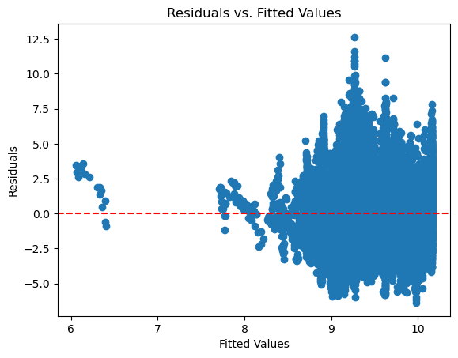

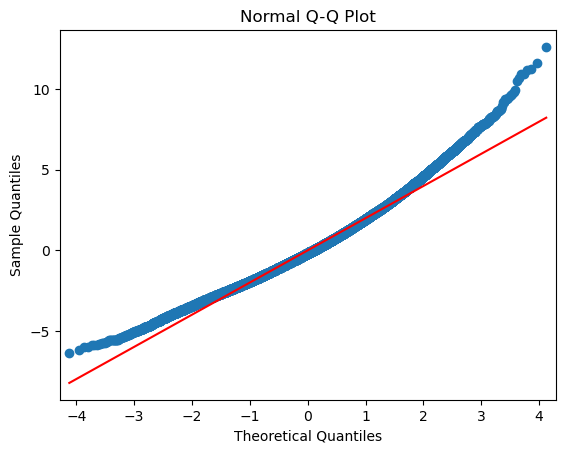

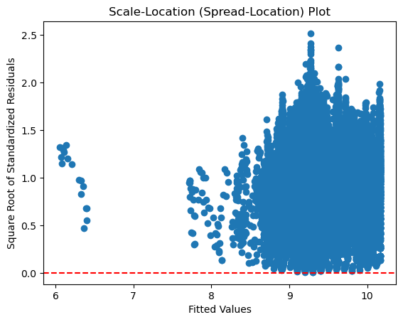

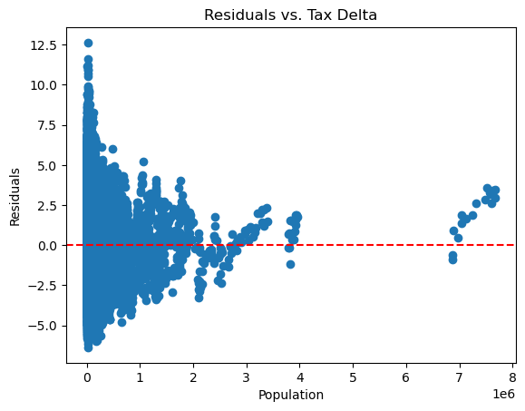

```python
# Validating for linearity assumptions

import statsmodels.api as sm
import matplotlib.pyplot as plt
import scipy.stats as stats
import numpy as np

# Assuming you have already fitted the linear regression model named 'model'

# Get fitted values and residuals
fitted_values = stats_model.fittedvalues
residuals = stats_model.resid

# 1. Residuals vs. Fitted Values Plot
plt.scatter(fitted_values, residuals)
plt.xlabel('Fitted Values')
plt.ylabel('Residuals')
plt.title('Residuals vs. Fitted Values')
plt.axhline(y=0, color='r', linestyle='--')  # Add a horizontal line at y=0
plt.show()

# 2. Normal Q-Q Plot
sm.qqplot(residuals, line='s')
plt.title('Normal Q-Q Plot')
plt.show()

# 3. Scale-Location (Spread-Location) Plot
sqrt_standardized_residuals = np.sqrt(np.abs(stats_model.get_influence().resid_studentized_internal))
plt.scatter(fitted_values, sqrt_standardized_residuals)
plt.xlabel('Fitted Values')
plt.ylabel('Square Root of Standardized Residuals')
plt.title('Scale-Location (Spread-Location) Plot')
plt.axhline(y=0, color='r', linestyle='--')  # Add a horizontal line at y=0
plt.show()

# 4. Residuals vs. Predictor Plot for ''
plt.scatter(df_diab_total_pivot['Population'], residuals)
plt.xlabel('Population')
plt.ylabel('Residuals')
plt.title('Residuals vs. Tax Delta')
plt.axhline(y=0, color='r', linestyle='--')  # Add a horizontal line at y=0
plt.show()
```

##### Since the above model violates linearity assumptions, applying Box-Cox transformation

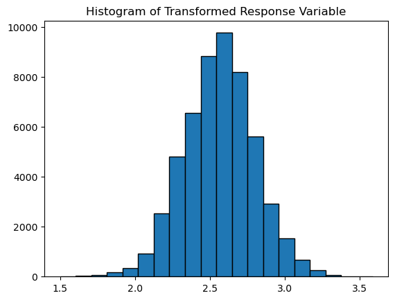

```
Lambda Value: 0.08513380502286896
                            OLS Regression Results
==============================================================================
Dep. Variable:                      y   R-squared:                       0.022
Model:                            OLS   Adj. R-squared:                  0.022
Method:                 Least Squares   F-statistic:                     408.5
Date:                Sat, 25 Nov 2023   Prob (F-statistic):          2.28e-262
Time:                        15:08:20   Log-Likelihood:                 1895.3
No. Observations:               53318   AIC:                            -3783.
Df Residuals:                   53314   BIC:                            -3747.
Df Model:                           3
Covariance Type:            nonrobust
==================================================================================
                     coef    std err          t      P>|t|      [0.025      0.975]
----------------------------------------------------------------------------------
const              2.5097      0.003    761.206      0.000       2.503       2.516
Grocery Tax        1.3189      0.049     26.969      0.000       1.223       1.415
Restaurant Tax     0.8106      0.061     13.353      0.000       0.692       0.930
Population     -5.258e-08   4.34e-09    -12.115      0.000   -6.11e-08   -4.41e-08
==============================================================================
Omnibus:                      113.515   Durbin-Watson:                   0.489
Prob(Omnibus):                  0.000   Jarque-Bera (JB):              143.017
Skew:                           0.000   Prob(JB):                     8.79e-32
Kurtosis:                       3.254   Cond. No.                     1.51e+07
==============================================================================

Notes:
[1] Standard Errors assume that the covariance matrix of the errors is correctly specified.
[2] The condition number is large, 1.51e+07. This might indicate that there are
strong multicollinearity or other numerical problems.
```

```python
# Applying the Box-Cox transformation

# Apply Box-Cox Transformation to Response Variable
y_transformed, lambda_value = stats.boxcox(y + 1)  # Adding 1 to handle zero values

# Visualize the Transformed Response Variable
plt.hist(y_transformed, bins=20, edgecolor='black')
plt.title('Histogram of Transformed Response Variable')
plt.show()

# Check Lambda Value
print(f'Lambda Value: {lambda_value}')

# Fit a new model using the transformed response variable
stats_model_transformed = sm.OLS(y_transformed, X).fit()

# Print the summary of the transformed model
print(stats_model_transformed.summary())
```

##### Since, we do not get a good R-square value, even after fixing assumtpions by transforming, we drop further investigation.

#### 3. With multiple controls

##### a. Total Population and Gender - On Percentage

```python
import numpy as np
import pandas as pd
import statsmodels.api as sm
from sklearn.model_selection import train_test_split
from sklearn.linear_model import LinearRegression
from sklearn.metrics import mean_squared_error, r2_score

# Assuming 'Grocery Tax' and 'Restaurant Tax' are the features
X = pd.get_dummies(df_diab_gender_pivot[['Grocery Tax', 'Restaurant Tax','Population', 'Gender']], columns=['Gender'], drop_first=True)
y = df_diab_gender_pivot['Gender Percentage']

# Add a constant term to the features matrix (required for statsmodels)
X = sm.add_constant(X)

# Create and fit the linear regression model using statsmodels
stats_model = sm.OLS(y, X).fit()

# Print the summary
print(stats_model.summary())
```

```
                            OLS Regression Results
==============================================================================
Dep. Variable:      Gender Percentage   R-squared:                       0.053
Model:                            OLS   Adj. R-squared:                  0.053
Method:                 Least Squares   F-statistic:                     1485.
Date:                Sat, 25 Nov 2023   Prob (F-statistic):               0.00
Time:                        15:08:20   Log-Likelihood:            -2.2715e+05
No. Observations:              106631   AIC:                         4.543e+05
Df Residuals:                  106626   BIC:                         4.544e+05
Df Model:                           4
Covariance Type:            nonrobust
==================================================================================
                     coef    std err          t      P>|t|      [0.025      0.975]
----------------------------------------------------------------------------------
const              8.5508      0.021    402.018      0.000       8.509       8.593
Grocery Tax       11.7227      0.302     38.869      0.000      11.132      12.314
Restaurant Tax     6.1458      0.374     16.416      0.000       5.412       6.880
Population     -8.586e-07   5.35e-08    -16.051      0.000   -9.63e-07   -7.54e-07
Gender_Male        0.7444      0.012     59.674      0.000       0.720       0.769
==============================================================================
Omnibus:                     7424.468   Durbin-Watson:                   0.376
Prob(Omnibus):                  0.000   Jarque-Bera (JB):            10022.083
Skew:                           0.618   Prob(JB):                         0.00
Kurtosis:                       3.855   Cond. No.                     7.53e+06
==============================================================================

Notes:
[1] Standard Errors assume that the covariance matrix of the errors is correctly specified.
[2] The condition number is large, 7.53e+06. This might indicate that there are
strong multicollinearity or other numerical problems.
```

##### Conclusion:

- One percent increase in grocery tax, keeping all other constant, increases the diabetics % by 11.72%.
- One percent increase in restaurant tax, keeping all other constant, increases the diabetics % by 6.14%.
- One unit increase in population, keeping all other constant, decreases the diabetics number by 8.58x10^-7
- Adjusted R-square is 0.053 indicating that the model can explain only 5.3% of variation in diabetics %
- The conditional number is large and hence we need to check for multicollinearity

```python
# Checking for multicollinearity
from statsmodels.stats.outliers_influence import variance_inflation_factor

vif_data = pd.DataFrame()
vif_data["Variable"] = X.columns
vif_data["VIF"] = [variance_inflation_factor(X.values, i) for i in range(X.shape[1])]

# Check the VIF values
print(vif_data)
```

```
         Variable        VIF
0           const  11.629348
1     Grocery Tax   1.031369
2  Restaurant Tax   1.027660
3      Population   1.016198
4     Gender_Male   1.000082
```

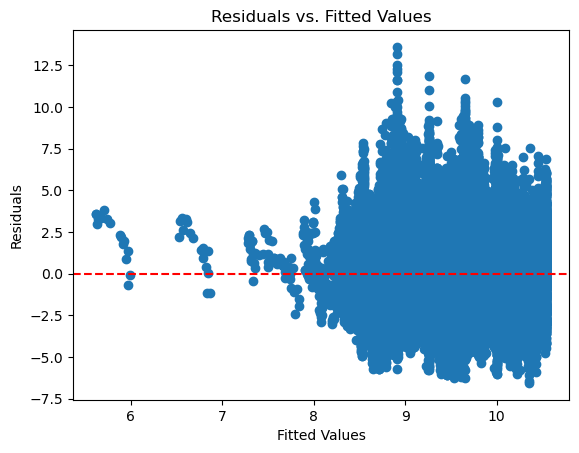

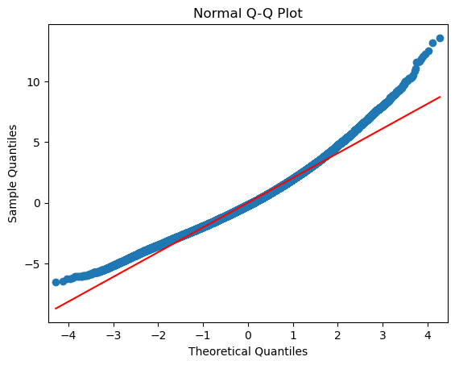

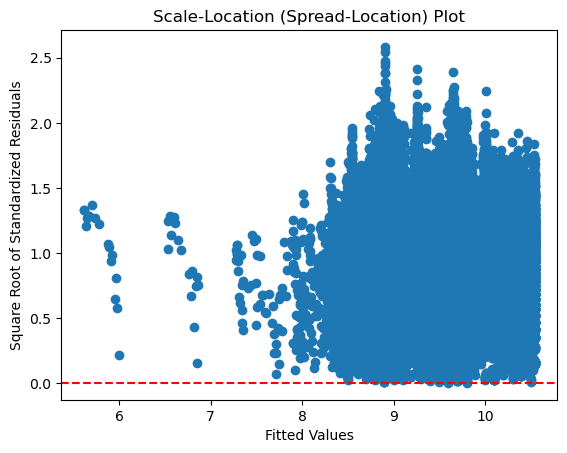

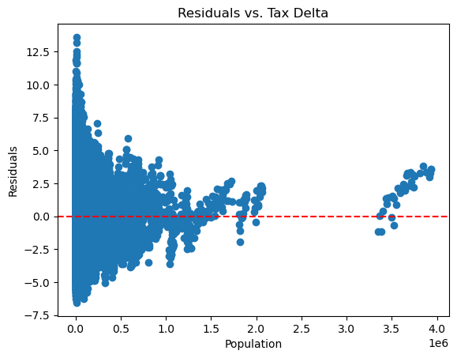

```python
# Validating for linearity assumptions

import statsmodels.api as sm
import matplotlib.pyplot as plt
import scipy.stats as stats
import numpy as np

# Assuming you have already fitted the linear regression model named 'model'

# Get fitted values and residuals
fitted_values = stats_model.fittedvalues
residuals = stats_model.resid

# 1. Residuals vs. Fitted Values Plot
plt.scatter(fitted_values, residuals)
plt.xlabel('Fitted Values')
plt.ylabel('Residuals')
plt.title('Residuals vs. Fitted Values')
plt.axhline(y=0, color='r', linestyle='--')  # Add a horizontal line at y=0
plt.show()

# 2. Normal Q-Q Plot
sm.qqplot(residuals, line='s')
plt.title('Normal Q-Q Plot')
plt.show()

# 3. Scale-Location (Spread-Location) Plot
sqrt_standardized_residuals = np.sqrt(np.abs(stats_model.get_influence().resid_studentized_internal))
plt.scatter(fitted_values, sqrt_standardized_residuals)
plt.xlabel('Fitted Values')
plt.ylabel('Square Root of Standardized Residuals')
plt.title('Scale-Location (Spread-Location) Plot')
plt.axhline(y=0, color='r', linestyle='--')  # Add a horizontal line at y=0
plt.show()

# 4. Residuals vs. Predictor Plot for ''
plt.scatter(df_diab_gender_pivot['Population'], residuals)
plt.xlabel('Population')
plt.ylabel('Residuals')
plt.title('Residuals vs. Tax Delta')
plt.axhline(y=0, color='r', linestyle='--')  # Add a horizontal line at y=0
plt.show()
```

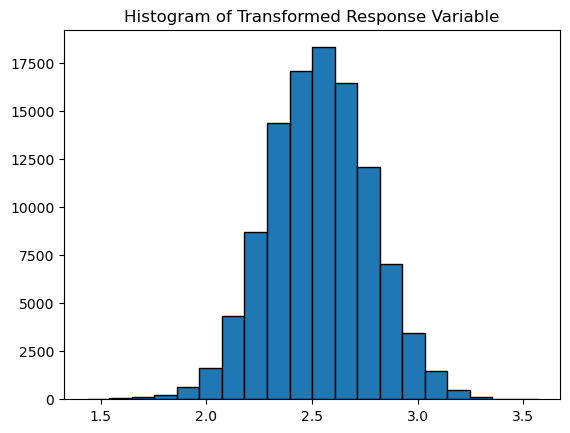

```
Lambda Value: 0.07576771896055827
                            OLS Regression Results
==============================================================================
Dep. Variable:                      y   R-squared:                       0.055
Model:                            OLS   Adj. R-squared:                  0.055
Method:                 Least Squares   F-statistic:                     1539.
Date:                Sat, 25 Nov 2023   Prob (F-statistic):               0.00
Time:                        15:08:25   Log-Likelihood:                 4284.6
No. Observations:              106631   AIC:                            -8559.
Df Residuals:                  106626   BIC:                            -8511.
Df Model:                           4
Covariance Type:            nonrobust
==================================================================================
                     coef    std err          t      P>|t|      [0.025      0.975]
----------------------------------------------------------------------------------
const              2.4376      0.002   1004.183      0.000       2.433       2.442
Grocery Tax        1.2882      0.034     37.425      0.000       1.221       1.356
Restaurant Tax     0.8002      0.043     18.728      0.000       0.716       0.884
Population     -1.013e-07   6.11e-09    -16.598      0.000   -1.13e-07   -8.94e-08
Gender_Male        0.0875      0.001     61.456      0.000       0.085       0.090
==============================================================================
Omnibus:                      295.117   Durbin-Watson:                   0.363
Prob(Omnibus):                  0.000   Jarque-Bera (JB):              383.372
Skew:                           0.016   Prob(JB):                     5.65e-84
Kurtosis:                       3.292   Cond. No.                     7.53e+06
==============================================================================

Notes:
[1] Standard Errors assume that the covariance matrix of the errors is correctly specified.
[2] The condition number is large, 7.53e+06. This might indicate that there are
strong multicollinearity or other numerical problems.
```

```python
# Applying the Box-Cox transformation

# Apply Box-Cox Transformation to Response Variable
y_transformed, lambda_value = stats.boxcox(y + 1)  # Adding 1 to handle zero values

# Visualize the Transformed Response Variable
plt.hist(y_transformed, bins=20, edgecolor='black')
plt.title('Histogram of Transformed Response Variable')
plt.show()

# Check Lambda Value
print(f'Lambda Value: {lambda_value}')

# Fit a new model using the transformed response variable
stats_model_transformed = sm.OLS(y_transformed, X).fit()

# Print the summary of the transformed model
print(stats_model_transformed.summary())
```

##### Conclusion:

Since Adj. R square of this model is low, we will ignore further discussion

##### b. Total Population and Age - On Percentage

```python
import numpy as np
import pandas as pd
import statsmodels.api as sm
from sklearn.model_selection import train_test_split
from sklearn.linear_model import LinearRegression
from sklearn.metrics import mean_squared_error, r2_score

# Assuming 'Grocery Tax' and 'Restaurant Tax' are the features
X = pd.get_dummies(df_diab_age_pivot[['Grocery Tax', 'Restaurant Tax', 'Population','Age']], columns=['Age'], drop_first=True)
y = df_diab_age_pivot['Age Diabetics Percentage']

# Add a constant term to the features matrix (required for statsmodels)
X = sm.add_constant(X)

# Create and fit the linear regression model using statsmodels
stats_model = sm.OLS(y, X).fit()

# Print the summary
print(stats_model.summary())
```

```
                               OLS Regression Results
====================================================================================
Dep. Variable:     Age Diabetics Percentage   R-squared:                       0.865
Model:                                  OLS   Adj. R-squared:                  0.865
Method:                       Least Squares   F-statistic:                 2.032e+05
Date:                      Sat, 25 Nov 2023   Prob (F-statistic):               0.00
Time:                              15:08:25   Log-Likelihood:            -3.6574e+05
No. Observations:                    158645   AIC:                         7.315e+05
Df Residuals:                        158639   BIC:                         7.316e+05
Df Model:                                 5
Covariance Type:                  nonrobust
==================================================================================
                     coef    std err          t      P>|t|      [0.025      0.975]
----------------------------------------------------------------------------------
const              2.4043      0.022    109.783      0.000       2.361       2.447
Grocery Tax       15.2141      0.294     51.728      0.000      14.638      15.791
Restaurant Tax     4.4753      0.368     12.176      0.000       3.755       5.196
Population      1.132e-06   7.22e-08     15.682      0.000    9.91e-07    1.27e-06
Age_45-64          8.5523      0.015    571.403      0.000       8.523       8.582
Age_65-beyond     15.0361      0.015   1000.620      0.000      15.007      15.066
==============================================================================
Omnibus:                    30055.782   Durbin-Watson:                   0.771
Prob(Omnibus):                  0.000   Jarque-Bera (JB):            84074.279
Skew:                           1.012   Prob(JB):                         0.00
Kurtosis:                       5.936   Cond. No.                     5.46e+06
==============================================================================

Notes:
[1] Standard Errors assume that the covariance matrix of the errors is correctly specified.
[2] The condition number is large, 5.46e+06. This might indicate that there are
strong multicollinearity or other numerical problems.
```

##### Conclusion:

- One percent increase in grocery tax, keeping all other constant, increases the diabetics % by 15.21.
- One percent increase in restaurant tax, keeping all other constant, increases the diabetics % by 4.47.
- One unit increase in population, keeping all other constant, increases the diabetics % by 1.13x10^-6
- Adjusted R-square is 0.865 indicating that the model can explain only 86.5% of variation in % diabetics
- The conditional number is large and hence we need to check for multicollinearity
- This model has good R-square value but we need to validate the linearity assumptions and if any is violated, apply necessary trasformation

```python
# Checking for multicollinearity
from statsmodels.stats.outliers_influence import variance_inflation_factor

vif_data = pd.DataFrame()
vif_data["Variable"] = X.columns
vif_data["VIF"] = [variance_inflation_factor(X.values, i) for i in range(X.shape[1])]

# Check the VIF values
print(vif_data)
```

```
         Variable        VIF
0           const  12.922238
1     Grocery Tax   1.029523
2  Restaurant Tax   1.026040
3      Population   1.023592
4       Age_45-64   1.346604
5   Age_65-beyond   1.357207
```

##### Inference:

The VIF for predictor variables is small and hence multicollinearity does not exist The VIF with constant variable is high. This can be fixed by scaling if needed.

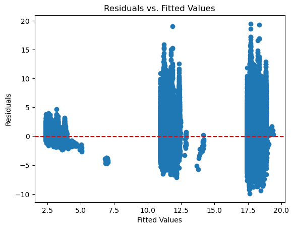

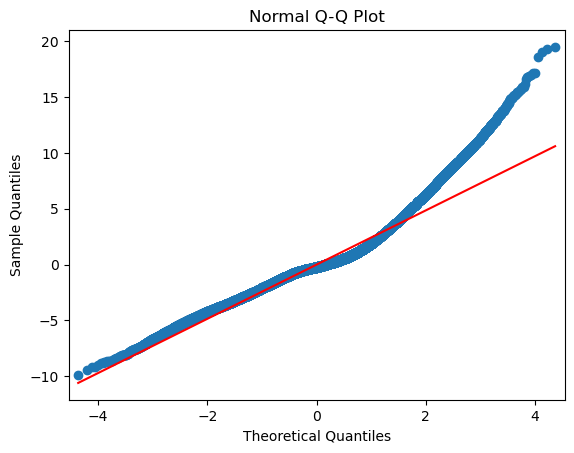

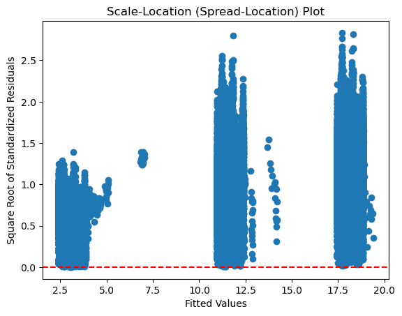

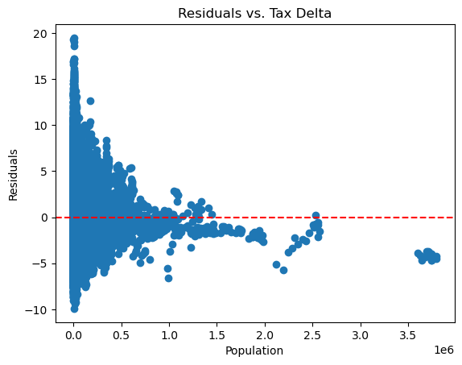

```python
# Validating for linearity assumptions

import statsmodels.api as sm
import matplotlib.pyplot as plt
import scipy.stats as stats
import numpy as np

# Assuming you have already fitted the linear regression model named 'model'

# Get fitted values and residuals
fitted_values = stats_model.fittedvalues
residuals = stats_model.resid

# 1. Residuals vs. Fitted Values Plot
plt.scatter(fitted_values, residuals)
plt.xlabel('Fitted Values')
plt.ylabel('Residuals')
plt.title('Residuals vs. Fitted Values')
plt.axhline(y=0, color='r', linestyle='--')  # Add a horizontal line at y=0
plt.show()

# 2. Normal Q-Q Plot
sm.qqplot(residuals, line='s')
plt.title('Normal Q-Q Plot')
plt.show()

# 3. Scale-Location (Spread-Location) Plot
sqrt_standardized_residuals = np.sqrt(np.abs(stats_model.get_influence().resid_studentized_internal))
plt.scatter(fitted_values, sqrt_standardized_residuals)
plt.xlabel('Fitted Values')
plt.ylabel('Square Root of Standardized Residuals')
plt.title('Scale-Location (Spread-Location) Plot')
plt.axhline(y=0, color='r', linestyle='--')  # Add a horizontal line at y=0
plt.show()

# 4. Residuals vs. Predictor Plot for ''
plt.scatter(df_diab_age_pivot['Population'], residuals)
plt.xlabel('Population')
plt.ylabel('Residuals')
plt.title('Residuals vs. Tax Delta')
plt.axhline(y=0, color='r', linestyle='--')  # Add a horizontal line at y=0
plt.show()
```

##### Since the above model violates linearity assumptions, applying Box-Cox transoformation

```python
# Applying the Box-Cox transformation

# Apply Box-Cox Transformation to Response Variable
y_transformed, lambda_value = stats.boxcox(y + 1)  # Adding 1 to handle zero values

# Visualize the Transformed Response Variable
plt.hist(y_transformed, bins=20, edgecolor='black')
plt.title('Histogram of Transformed Response Variable')
plt.show()

# Check Lambda Value
print(f'Lambda Value: {lambda_value}')

# Fit a new model using the transformed response variable
stats_model_transformed = sm.OLS(y_transformed, X).fit()

# Print the summary of the transformed model
print(stats_model_transformed.summary())
```

[output not shown]

```
Lambda Value: 0.5100811843716125
                            OLS Regression Results
==============================================================================
Dep. Variable:                      y   R-squared:                       0.909
Model:                            OLS   Adj. R-squared:                  0.909
Method:                 Least Squares   F-statistic:                 3.182e+05
Date:                Sat, 25 Nov 2023   Prob (F-statistic):               0.00
Time:                        15:08:31   Log-Likelihood:            -1.5255e+05
No. Observations:              158645   AIC:                         3.051e+05
Df Residuals:                  158639   BIC:                         3.052e+05
Df Model:                           5
Covariance Type:            nonrobust
==================================================================================
                     coef    std err          t      P>|t|      [0.025      0.975]
----------------------------------------------------------------------------------
const              1.8114      0.006    317.090      0.000       1.800       1.823
Grocery Tax        4.3286      0.077     56.421      0.000       4.178       4.479
Restaurant Tax     1.0880      0.096     11.348      0.000       0.900       1.276
Population      3.476e-07   1.88e-08     18.460      0.000    3.11e-07    3.85e-07
Age_45-64          3.1566      0.004    808.536      0.000       3.149       3.164
Age_65-beyond      4.8547      0.004   1238.545      0.000       4.847       4.862
==============================================================================
Omnibus:                    14171.832   Durbin-Watson:                   0.520
Prob(Omnibus):                  0.000   Jarque-Bera (JB):            23240.485
Skew:                           0.663   Prob(JB):                         0.00
Kurtosis:                       4.326   Cond. No.                     5.46e+06
==============================================================================

Notes:
[1] Standard Errors assume that the covariance matrix of the errors is correctly specified.
[2] The condition number is large, 5.46e+06. This might indicate that there are
strong multicollinearity or other numerical problems.
```

##### Conclusion:

- The lambda value is 0.51. Indicating the new model fit is on (((% diabetics^0.51)-1)/0.51). We will call this response as transformed y.
- One percent increase in grocery tax, keeping all other constant, increases the transformed y by 4.33
- One percent increase in restaurant tax, keeping all other constant, increases the transformed by 1.08.
- One unit increase in population, keeping all other constant, increases the transformed y by 3.47x10^-7.
- All p-value are statistically significant
- Adjusted R-square is 0.909 indicating that the model can explain only 90.9% of variation in % diabetics
- Conditonal large number error can be fixed by scaling

```python
import statsmodels.api as sm
from sklearn.preprocessing import StandardScaler
import pandas as pd

df_diab_scaled = df_diab_age_pivot.reset_index(drop=True)
df_diab_scaled

# Extract the independent variables (features) from your DataFrame
X = pd.get_dummies(df_diab_scaled[['Grocery Tax', 'Restaurant Tax','Population', 'Age']], columns=['Age'], drop_first=True)
# Extract the dependent variable from your DataFrame
y = df_diab_scaled['Age Diabetics Percentage']

# Initialize the StandardScaler
scaler = StandardScaler()

# Fit and transform the independent variables
X_scaled = scaler.fit_transform(X)

# Create a new DataFrame with the scaled features
X_scaled_df = pd.DataFrame(X_scaled, columns=X.columns)

# Add a constant term to the independent variables
X_scaled_df = sm.add_constant(X_scaled_df)

# Fit the linear regression model
model = sm.OLS(y, X_scaled_df).fit()

# Display the summary
print(model.summary())
```

```
                               OLS Regression Results
====================================================================================
Dep. Variable:     Age Diabetics Percentage   R-squared:                       0.865
Model:                                  OLS   Adj. R-squared:                  0.865
Method:                       Least Squares   F-statistic:                 2.032e+05
Date:                      Sat, 25 Nov 2023   Prob (F-statistic):               0.00
Time:                              15:08:32   Log-Likelihood:            -3.6574e+05
No. Observations:                    158645   AIC:                         7.315e+05
Df Residuals:                        158639   BIC:                         7.316e+05
Df Model:                                 5
Covariance Type:                  nonrobust
==================================================================================
                     coef    std err          t      P>|t|      [0.025      0.975]
----------------------------------------------------------------------------------
const             10.7812      0.006   1769.654      0.000      10.769      10.793
Grocery Tax        0.3198      0.006     51.728      0.000       0.308       0.332
Restaurant Tax     0.0751      0.006     12.176      0.000       0.063       0.087
Population         0.0967      0.006     15.682      0.000       0.085       0.109
Age_45-64          4.0396      0.007    571.403      0.000       4.026       4.053
Age_65-beyond      7.1018      0.007   1000.620      0.000       7.088       7.116
==============================================================================
Omnibus:                    30055.782   Durbin-Watson:                   0.771
Prob(Omnibus):                  0.000   Jarque-Bera (JB):            84074.279
Skew:                           1.012   Prob(JB):                         0.00
Kurtosis:                       5.936   Cond. No.                         1.76
==============================================================================

Notes:
[1] Standard Errors assume that the covariance matrix of the errors is correctly specified.
```

##### Since the above model violates linearity assumptions, applying Box-Cox transformation to scaled parameters

```python
# Applying the Box-Cox transformation

# Apply Box-Cox Transformation to Response Variable
y_transformed, lambda_value = stats.boxcox(y + 1)  # Adding 1 to handle zero values

# Visualize the Transformed Response Variable
plt.hist(y_transformed, bins=20, edgecolor='black')
plt.title('Histogram of Transformed Response Variable')
plt.show()

# Check Lambda Value
print(f'Lambda Value: {lambda_value}')

# Fit a new model using the transformed response variable
stats_model_transformed = sm.OLS(y_transformed, X_scaled_df).fit()

# Print the summary of the transformed model
print(stats_model_transformed.summary())
```

[output not shown]

```
Lambda Value: 0.5100811843716125
                            OLS Regression Results
==============================================================================
Dep. Variable:                      y   R-squared:                       0.909
Model:                            OLS   Adj. R-squared:                  0.909
Method:                 Least Squares   F-statistic:                 3.182e+05
Date:                Sat, 25 Nov 2023   Prob (F-statistic):               0.00
Time:                        15:08:32   Log-Likelihood:            -1.5255e+05
No. Observations:              158645   AIC:                         3.051e+05
Df Residuals:                  158639   BIC:                         3.052e+05
Df Model:                           5
Covariance Type:            nonrobust
==================================================================================
                     coef    std err          t      P>|t|      [0.025      0.975]
----------------------------------------------------------------------------------
const              4.6225      0.002   2908.788      0.000       4.619       4.626
Grocery Tax        0.0910      0.002     56.421      0.000       0.088       0.094
Restaurant Tax     0.0183      0.002     11.348      0.000       0.015       0.021
Population         0.0297      0.002     18.460      0.000       0.027       0.033
Age_45-64          1.4910      0.002    808.536      0.000       1.487       1.495
Age_65-beyond      2.2930      0.002   1238.545      0.000       2.289       2.297
==============================================================================
Omnibus:                    14171.832   Durbin-Watson:                   0.520
Prob(Omnibus):                  0.000   Jarque-Bera (JB):            23240.485
Skew:                           0.663   Prob(JB):                         0.00
Kurtosis:                       4.326   Cond. No.                         1.76
==============================================================================

Notes:
[1] Standard Errors assume that the covariance matrix of the errors is correctly specified.
```

##### Conclusion:

- The lambda value is 0.51. Indicating the new model fit is on (((% diabetics^0.51)-1)/0.51). We will call this response as transformed y.
- One percent increase in scaled grocery tax, keeping all other constant, increases the transformed y by 0.09
- One percent increase in scaled restaurant tax, keeping all other constant, increases the transformed by 0.02.
- One unit increase in population, keeping all other constant, increases the transformed y by 0.03.
- All p-value are statistically significant
- Adjusted R-square is 0.909 indicating that the model can explain only 90.9% of variation in % diabetics

### Final Conclusion:

- The best model for Diabetics % variation with Tax, after accounting for necessary controls and corrections of assumptions, is the model with response, (((% diabetics^0.51)-1)/0.51); and scaled predictor grocery tax, restaurant tax, population and age control
- This model explains for 90.9% variability in diabetics %
- We shall continue to research the impact by variation on tax delta.